# Numbers

Session 27: Building a Poverty Index, Step by Step

Ayush Patel

National Law School of India University, Bengaluru

08 Sep, 2026

# Why build an index at all?

## One number, many decisions

A poverty index turns raw information into one number.

That number can guide targeting and policy.

## But it hides choices

Every index makes normative choices along the way.

Today we make those choices ourselves, one at a time.

## Two jobs any poverty measure must do

Any multidimensional poverty measure answers two questions (Alkire et al. 2015).

**Identification**: who counts as poor?

**Aggregation**: how do we turn that into one number?

## Our plan for today

We will build our own small index from scratch.

We will use the same method behind the global Multidimensional Poverty Index (gMPI) (Oxford Poverty and Human Development Initiative and United Nations Development Programme 2024).

By the end, we will compute our own version of the adjusted headcount ratio.

# Meet the class

## A classroom of six

We will track six students in a class.

Aditi, Zara, Rohan, Kabir, Meera, and Dev.

## What we will measure

We pick six everyday indicators.

They fall into three areas of student life.

## Three dimensions

**Wellbeing**: sleep, and breakfast habits.

**Learning**: reading for pleasure, and homework completion.

**Environment**: a quiet study space, and school supplies.

This mirrors how the gMPI groups indicators into health, education, and standard of living (Oxford Poverty and Human Development Initiative and United Nations Development Programme 2024).

# Step 1: The raw data

## The achievement matrix

We collect raw data for each student on each indicator.

This raw table is called the achievement matrix.

## Our achievement matrix

| Student | Sleep (hrs/night) | Breakfast skipped (days/wk) | Reading (min/wk) | Homework done (%) | Study space | Own supplies |
| --- | --- | --- | --- | --- | --- | --- |
| Aditi | 8 | 1 | 120 | 95 | Yes | Yes |
| Zara | 6 | 0 | 90 | 90 | Yes | Yes |
| Rohan | 5 | 4 | 75 | 85 | Yes | Yes |
| Kabir | 7.5 | 1 | 20 | 60 | Yes | Yes |
| Meera | 8 | 2 | 30 | 55 | No | Yes |
| Dev | 6 | 1 | 15 | 50 | No | Yes |

Six students. Six indicators. This is just raw data.

# Step 2: Setting cutoffs

## Who counts as deprived?

Raw numbers alone do not tell us who is deprived.

We need a line for each indicator.

## A normative decision

That line is called a deprivation cutoff.

Someone else could draw the line differently.

There is no purely mathematical answer here.

## Our six cutoffs

We treat a student as deprived in an indicator if:

Sleep is below 7 hours a night.

Breakfast is skipped on 3 or more days a week.

Reading for pleasure is below 60 minutes a week.

Homework completion is below 80 percent.

There is no quiet study space at home.

The student does not own the required school supplies.

## Same matrix, cutoffs added

| Student | Sleep (hrs/night) | Breakfast skipped (days/wk) | Reading (min/wk) | Homework done (%) | Study space | Own supplies |
| --- | --- | --- | --- | --- | --- | --- |
| Aditi | 8 | 1 | 120 | 95 | Yes | Yes |
| Zara | 6 | 0 | 90 | 90 | Yes | Yes |
| Rohan | 5 | 4 | 75 | 85 | Yes | Yes |
| Kabir | 7.5 | 1 | 20 | 60 | Yes | Yes |
| Meera | 8 | 2 | 30 | 55 | No | Yes |
| Dev | 6 | 1 | 15 | 50 | No | Yes |
| Cutoff (z) | < 7 | ≥ 3 | < 60 | < 80 | No | No |

The last row is the vector of deprivation cutoffs.

# Step 3: The deprivation matrix

## Apply the cutoffs

Compare each raw value against its cutoff.

If a student falls short, mark a 1.

If not, mark a 0.

## The deprivation matrix

| Student | Sleep | Breakfast | Reading | Homework | Study space | Supplies |
| --- | --- | --- | --- | --- | --- | --- |
| Aditi | 0 | 0 | 0 | 0 | 0 | 0 |
| Zara | 1 | 0 | 0 | 0 | 0 | 0 |
| Rohan | 1 | 1 | 0 | 0 | 0 | 0 |
| Kabir | 0 | 0 | 1 | 1 | 0 | 0 |
| Meera | 0 | 0 | 1 | 1 | 1 | 0 |
| Dev | 1 | 0 | 1 | 1 | 1 | 0 |

1 means deprived. 0 means not deprived.

## A quick read of the matrix

Notice something about the Supplies column.

Every student has school supplies.

An indicator can exist and still show no deprivation at all.

# Step 4: Weights

## Not every indicator by itself

We already grouped our six indicators into three dimensions.

Wellbeing, Learning, and Environment.

## Equal dimensions, equal indicators

We treat all three dimensions as equally important.

Each dimension gets one third of the total weight.

## Splitting the weight within a dimension

Each dimension has two indicators.

So each indicator gets one half of its dimension’s weight.

One third split two ways is one sixth.

## Our weight vector

$$w = \left(\tfrac{1}{6},\ \tfrac{1}{6},\ \tfrac{1}{6},\ \tfrac{1}{6},\ \tfrac{1}{6},\ \tfrac{1}{6}\right)$$

Every indicator gets a weight of one sixth.

The six weights sum to one.

## The weighted deprivation matrix

| Student | Sleep (1/6) | Breakfast (1/6) | Reading (1/6) | Homework (1/6) | Study space (1/6) | Supplies (1/6) |
| --- | --- | --- | --- | --- | --- | --- |
| Aditi | 0 | 0 | 0 | 0 | 0 | 0 |
| Zara | 1/6 | 0 | 0 | 0 | 0 | 0 |
| Rohan | 1/6 | 1/6 | 0 | 0 | 0 | 0 |
| Kabir | 0 | 0 | 1/6 | 1/6 | 0 | 0 |
| Meera | 0 | 0 | 1/6 | 1/6 | 1/6 | 0 |
| Dev | 1/6 | 0 | 1/6 | 1/6 | 1/6 | 0 |

Every deprivation is now worth one sixth.

# Step 5: The deprivation score

## Add up each row

For each student, add up their weighted deprivations.

This sum is that student’s deprivation score, $c$.

## Deprivation scores

| Student | Sleep (1/6) | Breakfast (1/6) | Reading (1/6) | Homework (1/6) | Study space (1/6) | Supplies (1/6) | c |
| --- | --- | --- | --- | --- | --- | --- | --- |
| Aditi | 0 | 0 | 0 | 0 | 0 | 0 | 0 |
| Zara | 1/6 | 0 | 0 | 0 | 0 | 0 | 1/6 |
| Rohan | 1/6 | 1/6 | 0 | 0 | 0 | 0 | 1/3 |
| Kabir | 0 | 0 | 1/6 | 1/6 | 0 | 0 | 1/3 |
| Meera | 0 | 0 | 1/6 | 1/6 | 1/6 | 0 | 1/2 |
| Dev | 1/6 | 0 | 1/6 | 1/6 | 1/6 | 0 | 2/3 |

The score ranges from 0 (no deprivations) to 1 (deprived in everything).

# Step 6: Identifying the poor

## Two extreme rules

One rule: count a student as poor if deprived in even one indicator.

This is called the union approach.

## The union approach is too wide

By the union rule, five of our six students count as poor.

Only Aditi, with a score of 0, escapes.

That feels too broad to be useful.

## The opposite extreme

Another rule: count a student as poor only if deprived in every single indicator.

This is called the intersection approach.

## The intersection approach is too narrow

By the intersection rule, zero students count as poor.

Nobody in our class is deprived in all six indicators.

That feels too narrow to be useful.

## We need something in between

The Alkire-Foster method uses a dual cutoff (Alkire et al. 2015).

One cutoff for each indicator, already set.

A second cutoff for how many weighted indicators make someone poor overall.

## Our poverty cutoff

We set the poverty cutoff at $k = \tfrac{1}{3}$.

A student is poor if their deprivation score is at least one third.

This is the same poverty cutoff used in the actual gMPI (Oxford Poverty and Human Development Initiative and United Nations Development Programme 2024).

## Who is poor?

| Student | c | Poor? (c ≥ 1/3) |
| --- | --- | --- |
| Aditi | 0 | No |
| Zara | 1/6 | No |
| Rohan | 1/3 | Yes |
| Kabir | 1/3 | Yes |
| Meera | 1/2 | Yes |
| Dev | 2/3 | Yes |

Four of our six students are multidimensionally poor.

# Step 7: Censoring

## Focus only on the poor

We only want the deprivations of poor students to count.

Aditi and Zara are not poor, even though Zara has one deprivation.

## Zero out the non-poor

We replace every deprivation of a non-poor student with 0.

This is called censoring.

## The censored deprivation matrix

| Student | Sleep (1/6) | Breakfast (1/6) | Reading (1/6) | Homework (1/6) | Study space (1/6) | Supplies (1/6) | c(k) |
| --- | --- | --- | --- | --- | --- | --- | --- |
| Aditi | 0 | 0 | 0 | 0 | 0 | 0 | 0 |
| Zara | 0 | 0 | 0 | 0 | 0 | 0 | 0 |
| Rohan | 1/6 | 1/6 | 0 | 0 | 0 | 0 | 1/3 |
| Kabir | 0 | 0 | 1/6 | 1/6 | 0 | 0 | 1/3 |
| Meera | 0 | 0 | 1/6 | 1/6 | 1/6 | 0 | 1/2 |
| Dev | 1/6 | 0 | 1/6 | 1/6 | 1/6 | 0 | 2/3 |

Zara’s one deprivation in Sleep is now censored away.

Only the four poor rows still carry any weight.

# Step 8: Incidence

## How many students are poor?

The headcount ratio, $H$, is the share of the population that is poor.

$$H = \frac{q}{n}$$

Here $q$ is the number of poor students and $n$ is the total.

## Our headcount ratio

$$H = \frac{4}{6} = \frac{2}{3} \approx 0.667$$

Two out of every three students in our class are poor.

# Step 9: Intensity

## How deprived are the poor?

Incidence alone does not say how badly off poor students are.

The intensity, $A$, is the average deprivation score among the poor only.

$$A = \frac{\sum_{i=1}^{q} c_i}{q}$$

## Our intensity

$$A = \frac{\tfrac{1}{3} + \tfrac{1}{3} + \tfrac{1}{2} + \tfrac{2}{3}}{4} = \frac{11}{24} \approx 0.458$$

On average, our poor students are deprived in about 45.8 percent of the weighted indicators.

# Step 10: The adjusted headcount ratio

## Multiply incidence by intensity

The adjusted headcount ratio, $M_0$, combines both partial measures.

$$M_0 = H \times A$$

## Our result

$$M_0 = \frac{2}{3} \times \frac{11}{24} = \frac{11}{36} \approx 0.306$$

This is our class’s gMPI style poverty index.

## What does 0.306 mean?

Our value is the share of all possible weighted deprivations that poor students actually experience.

It rewards fixing both how many are poor and how badly.

## Why not use H alone?

Suppose Dev became deprived in one more indicator.

$H$ would stay exactly 2/3, since Dev was already poor.

But $M_0$ would rise, since Dev’s deprivation score would rise.

This property is called dimensional monotonicity (Alkire et al. 2015).

The plain headcount ratio does not have it. $M_0$ does.

# Step 11: Breaking $M_0$ down by indicator

## Two kinds of headcount ratio

The uncensored headcount ratio of an indicator counts everyone who is deprived in it.

The censored headcount ratio counts only the poor who are deprived in it.

## Uncensored headcount ratios

| Indicator | Sleep | Breakfast | Reading | Homework | Study space | Supplies |
| --- | --- | --- | --- | --- | --- | --- |
| Deprived students | 3 of 6 | 1 of 6 | 3 of 6 | 3 of 6 | 2 of 6 | 0 of 6 |
| Uncensored ratio | 50.0% | 16.7% | 50.0% | 50.0% | 33.3% | 0.0% |

This counts Zara’s sleep deprivation, even though she is not poor.

## Censored headcount ratios

| Indicator | Sleep | Breakfast | Reading | Homework | Study space | Supplies |
| --- | --- | --- | --- | --- | --- | --- |
| Poor and deprived | 2 of 6 | 1 of 6 | 3 of 6 | 3 of 6 | 2 of 6 | 0 of 6 |
| Censored ratio, $h_j$ | 33.3% | 16.7% | 50.0% | 50.0% | 33.3% | 0.0% |

Zara’s sleep deprivation has dropped out. Rohan’s has not.

## $M_0$ is a weighted average of these ratios

$$M_0 = \sum_{j=1}^{6} w_j \, h_j$$

## Checking the arithmetic

$$M_0 = \tfrac{1}{6}(0.333 + 0.167 + 0.500 + 0.500 + 0.333 + 0) = \tfrac{11}{36} \approx 0.306$$

This matches the $M_0$ we already calculated from the censored matrix.

# Step 12: Percentage contribution

## Which indicator drives our poverty score?

We can ask how much each indicator contributes to $M_0$.

Our weights already sum to one, so no further rescaling is needed.

$$\text{Contribution}_j = \frac{w_j \times h_j}{M_0}$$

## Contribution by indicator

| Indicator | Sleep | Breakfast | Reading | Homework | Study space | Supplies |
| --- | --- | --- | --- | --- | --- | --- |
| $w_j \times h_j$ | 1/18 | 1/36 | 1/12 | 1/12 | 1/18 | 0 |
| Contribution (exact) | 2/11 | 1/11 | 3/11 | 3/11 | 2/11 | 0 |
| Contribution (%) | 18.2% | 9.1% | 27.3% | 27.3% | 18.2% | 0.0% |

These six exact fractions add up to $\tfrac{11}{11} = 1$, or 100 percent.

## From indicators to dimensions

Each dimension’s contribution is the sum of its own indicators’ exact fractions.

Wellbeing: $\tfrac{2}{11} + \tfrac{1}{11} = \tfrac{3}{11} \approx 27.3\%$.  
Learning: $\tfrac{3}{11} + \tfrac{3}{11} = \tfrac{6}{11} \approx 54.5\%$.  
Environment: $\tfrac{2}{11} + 0 = \tfrac{2}{11} \approx 18.2\%$.

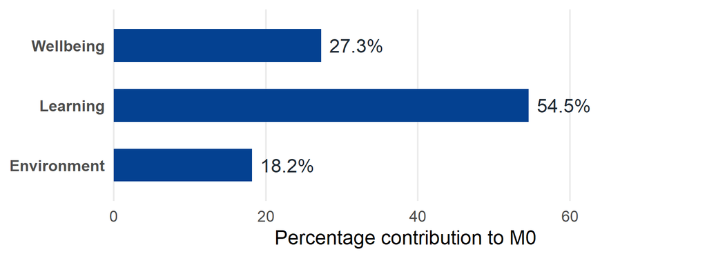

Figure 1

## Why not just add the rounded percentages?

$27.3\% + 27.3\%$ actually equals $54.6\%$, not $54.5\%$.

Rounding each indicator separately, then adding, can drift slightly from the true total.

Adding the exact fractions first, and rounding only at the end, avoids this.

## Reading the bars

Learning drives more than half of our class’s poverty score.

Wellbeing and Environment together drive the rest.

The three contributions add up to 100 percent.

# Step 13: Breaking $M_0$ down by group

## Subgroup decomposition

We can also split the class into two sections.

Overall poverty is a population share weighted sum of each section’s poverty (Alkire et al. 2015).

## Two sections

**Section A**  
Aditi, Rohan, Kabir

**Section B**  
Zara, Meera, Dev

Each section has three students.

## Section A’s numbers

Poor students in Section A: Rohan and Kabir.

$$H_A = \frac{2}{3}, \quad A_A = \frac{\tfrac{1}{3}+\tfrac{1}{3}}{2} = \frac{1}{3}$$

$$M_0^A = H_A \times A_A = \frac{2}{9} \approx 0.222$$

## Section B’s numbers

Poor students in Section B: Meera and Dev.

$$H_B = \frac{2}{3}, \quad A_B = \frac{\tfrac{1}{2}+\tfrac{2}{3}}{2} = \frac{7}{12}$$

$$M_0^B = H_B \times A_B = \frac{7}{18} \approx 0.389$$

## Putting the sections back together

$$M_0 = \frac{n_A}{n} M_0^A + \frac{n_B}{n} M_0^B$$

$$M_0 = \frac{1}{2}(0.222) + \frac{1}{2}(0.389) = 0.306$$

This matches our original class wide $M_0$ exactly.

## Why this matters for policy

Both sections have the same incidence of poverty.

But Section B’s poor students are more intensely deprived.

A single class average can hide this kind of difference.

# From our classroom to the real gMPI

## The same method, at a larger scale

Our worked example follows the exact same nine steps as the global MPI (Oxford Poverty and Human Development Initiative and United Nations Development Programme 2024).

Achievement matrix, cutoffs, deprivation matrix, weights, identification, censoring, incidence, intensity, and the adjusted headcount ratio.

## What actually changes

The real gMPI uses ten indicators across three dimensions: health, education, and standard of living.

Health and education each have two indicators, weighted one sixth each.

Standard of living has six indicators, weighted one eighteenth each.

The poverty cutoff is the same as ours: a deprivation score of one third or more (Oxford Poverty and Human Development Initiative and United Nations Development Programme 2024).

## The formulas do not change

$$H = \frac{q}{n}, \qquad A = \frac{\sum_{i=1}^{q} c_i}{q}, \qquad M_0 = H \times A$$

Whether the population is six students or an entire country, the formulas are identical.

## Recap of what we built today

We turned raw data into a deprivation matrix.

We weighted it, scored it, and applied a poverty cutoff.

We censored, aggregated, broke down by indicator, and decomposed by subgroup.

## References

Alkire, Sabina, James E. Foster, Suman Seth, Maria Emma Santos, Jose M. Roche, and Paola Ballon. 2015. *Multidimensional Poverty Measurement and Analysis*. Oxford University Press.

Oxford Poverty and Human Development Initiative, and United Nations Development Programme. 2024. *Global Multidimensional Poverty Index 2024: Poverty Amid Conflict, Technical Note*. UNDP; OPHI.